# fwdPathPaper

For each seed in the network, compute the mean infection size across the trials.

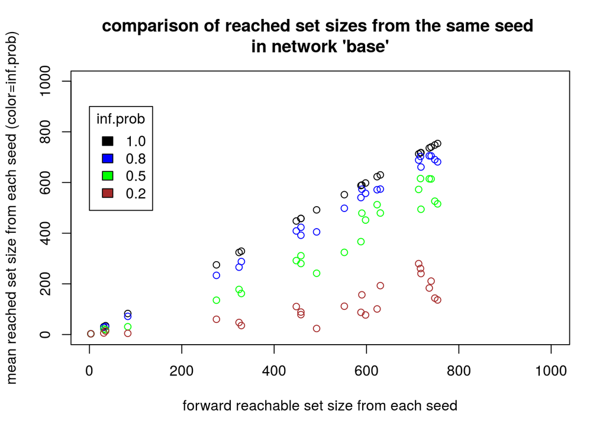

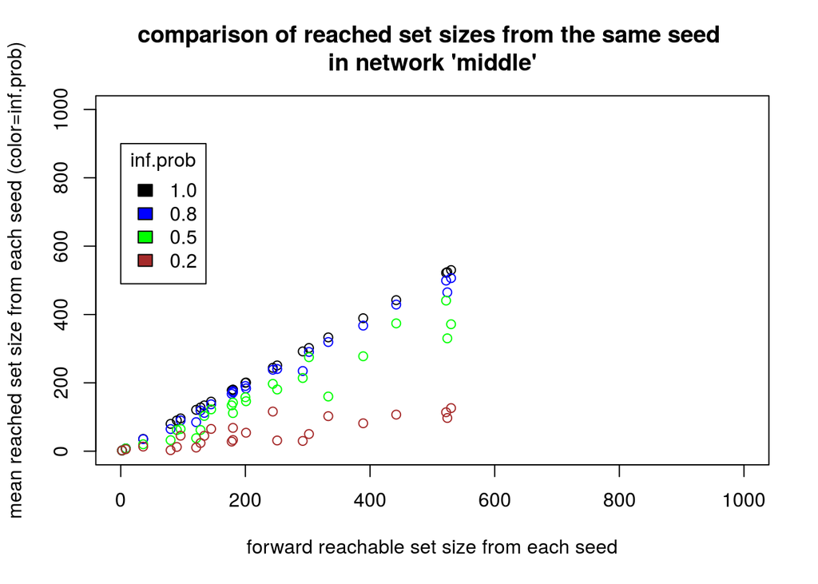

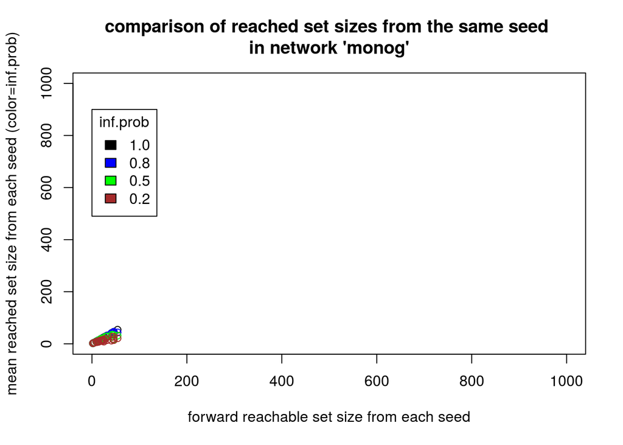

The scaling relationships seem to hold true across all three network condiations, just the overall size is dramatically reduced As inf.prob gets lower, the error bounds seem to get wider.

Although predicting the the distribution of infection sizes for low-probability transmission processes from the distribution of forward reachable set sizes may not yet be analytically tractable, we can definitly put some bounds on the expected sizes for individual seeds. In addition, we can certainly distinguish between the transmission potential of the three networks, something which might be quite difficult to do looking at their momentary characteristics. Of course, the networks examined are effectively ‘random’ within their parameter bounds. These expectations may not hold across other classes of networks (i.e. transit schedulaing)

TODO: can we simulate some networks with the same momentary degree distribution and edge durations where we have artifically reduced the transmission potential by increasing the local clustering (randomly distribute an attribute and add a nodematch term?). Also a network where we artificially increase the mixing (like a transit network) change partners in a deterministic round-robin?

### individual risk (probability of reach an individual vertex)

How useful is the earliest fwd path at finding the set of vertices most likely to be reached by infections?

There are number of factors that determine why some vertices may have a greater potential to infect the network than others. Some possibilities include:

- vertices with a higher total (aggregate) degree may simply have more neighbors to pass it on to
- vertices that are connected to others for a greater total length of time (tie duration) may have more transmission opertunities
- vertices that have ties early on may be able to do more damage because there is more time for the infection to propagate
- vertices with high sooness (a combination of reach and earlyness)

I expect that which of these effects are stronger may depend on properties of the infection process and the network

Are vertices with a low average tdist (when computed from a census or sample of other vertices) more likely to get hit? (or hit)

For the simulation runs done previously

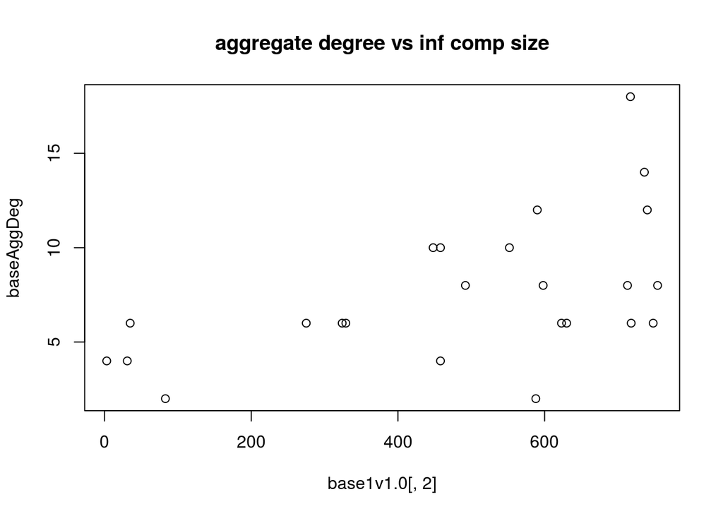

[output not shown]

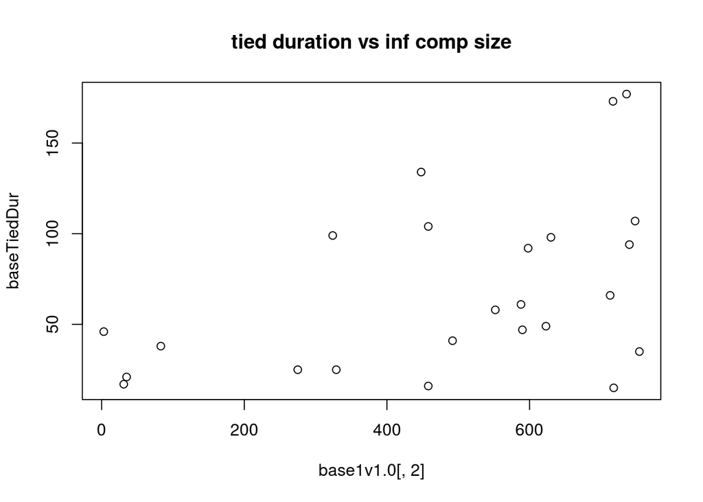

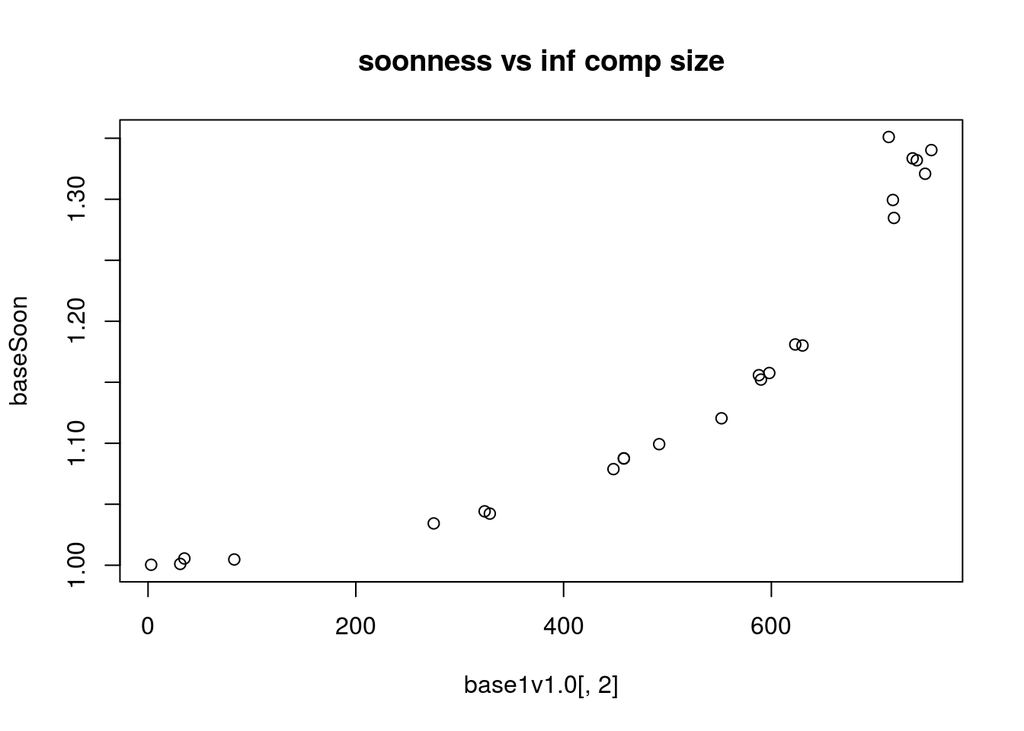

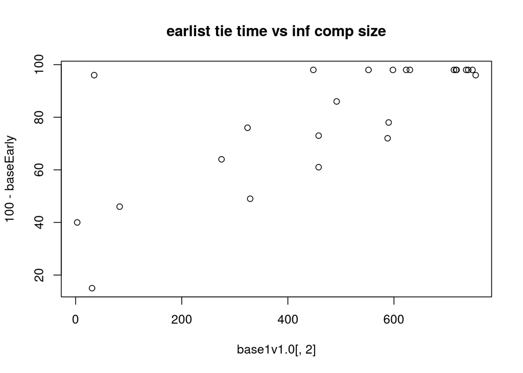

```r
cor(base1v1.0[,2],baseAggDeg)
```

```
## [1] 0.5265942
```

```r
cor(base1v1.0[,2],100-baseEarly)
```

```
## [1] 0.7603958
```

```r
cor(base1v1.0[,2],baseSoon)
```

```
## [1] 0.9007079
```

```r
cor(base1v1.0[,2],baseTiedDur)
```

```
## [1] 0.4583467
```

Sooness is the most strongly correlated, followd by the earlyness of ties. Although, it is kind of silly to include sooness, since it effectively calculates the inf.comp size anyway so it would be strange if it wasn’t highly correlated. Repeat for other network types.

## Relevance for real infection processes

Real-world datasets for sex contact networks are difficult to collect collected (’tho I think there is a dataset of sex-worker-client hookups from online dating service, Colorodo Springs). Can be modeled from ego nets. Can be used to efficiently estimate infection potential of various network models. Goodness-of-fit statistics for network models with explicit temporal components “Reality mining” contact network datasets increasingly common, may be feasible for things like influenza.

## Bibliography

Skye Bender-deMoll and Martina Morris (2012). *tsna: Tools for Temporal Social Network Analysis*. R package version 0.2. http://statnet.org http://CRAN.R-project.org/package=tsna

B. Bui Xuan, Afonso Ferreira, Aubin Jarry. *Computing shortest, fastest, and foremost journeys in dynamic networks*. RR-4589, 2002. https://hal.inria.fr/inria-00071996/document

Brandes, U. (2008). “On Variants of Shortest-Path Betweenness Centrality and their Generic Computation.”" Social Networks, 30, 136–145. https://kops.uni-konstanz.de/bitstream/handle/123456789/5940/variants.pdf

Carter T. Butts, Ayn Leslie-Cook, Pavel N. Krivitsky and Skye Bender-deMoll (2015). *networkDynamic: Dynamic Extensions for Network Objects*. R package version 0.9. http://statnet.org http://CRAN.R-project.org/package=networkDynamic

Moody, James. (2002) “The Importance of Relationship Timing for Diffusion.” *Social Forces* 81:25-56

Moody, James (2008) “Static Representations of Dynamic Networks” Duke Population Research Institute On-line Working Paper Series. http://papers.ccpr.ucla.edu/papers/PWP-DUKE-2009-009/PWP-DUKE-2009-009.pdf

Samuel Jenness (2015) *Modeling Epidemics over Observed Networks* R workbook http://statnet.github.io/gal/empnet.html

Samuel Jenness, Steven M. Goodreau and Martina Morris (2015). *EpiModel: Mathematical Modeling of Infectious Disease*. R package version 1.2.2. http://epimodel.org/